# Riddler - Skip to next song

Ravi Chandrasekaran

December 9, 2019

https://fivethirtyeight.com/features/how-fast-can-you-skip-to-your-favorite-song/ https://en.wikipedia.org/wiki/Negative_binomial_distribution#Waiting_time_in_a_Bernoulli_process

## General approach

When we are very close to our desired target, our gut tells us we should be patient and hit “next” a few times. When we’re ridiculously far away, our same gut says to hit “random” a few times, and hope that we get close. The question is how close is “close” – when should we be patient, and when should we try for better.

## Closeness

Let’s say our threshold for closeness is $n$ – that we are either on our desired square, or in the other $n - 1$ nearest, lesser squares. For example, if our target is 42, and our threshold was $n = 10$, then the “close” squares would include $33, 34, \dots, 42$.

If we land in the close squares, with all probabilities equal, then how many times would we expect to hit the next button? Well, if it’s an equal chance for each of these close squares, then the expectation is a simple calc:

$$\begin{align*}
E[F] = & \frac{1}{2}(n - 1) \\
\end{align*}$$

## Random steps

How many times would we expect to hit the “random” button before landing in the “close” zone?

Let’s start by assuming the starting position is outside the “close” zone. We’re basically looking at a geometric distribution, then, where the probability of failure and success is driven by the size of the closeness threshold.

What’s our chance ($p$) – of landing in the close zone? That’s defined by our closeness threshold and the total number of squares we’re considering – $p = n / N$. So, we can build up an equation entirely based on the cutoff and total number of squares, below:

$$\begin{align*}
p = & \frac{n}{N} \\
E[R \mid \text{not close}] = & \frac{1}{p}, && \text{from the geometric dist.} \\
= & \frac{N}{n} \\
\end{align*}$$

Now, we had started by assuming we were *outside* the close zone. Of course, if our starting position were lucky enough, we wouldn’t have any random steps at all. So:

$$\begin{align*}
E[R] = & (1 - p) \cdot E[R \mid \text{not close}] + p \cdot E[R \mid \text{close}] \\
= & (1 - \frac{n}{N}) \cdot \frac{N}{n} + \frac{N}{n} \cdot 0 \\
= & (\frac{N - n}{N}) \cdot \frac{N}{n} \\
= & \frac{N - n}{n} \\
= & \frac{N}{n} - 1 \\
\end{align*}$$

## Putting it together

Our total number of expected steps is the sum of the expected random button presses, and the expected number of forward button presses. These are both functions of the closeness threshold $n$, so once we have the formula, we’ll want to find the $n$ that minimizes the number of steps.

This is enough for us to plot the expected steps at each value of the closeness threshold $n$. Here, we’re first plotting all values, and then limiting it to just those values close to the minimum. From here, we can eyeball the minimum at $n = 14$.

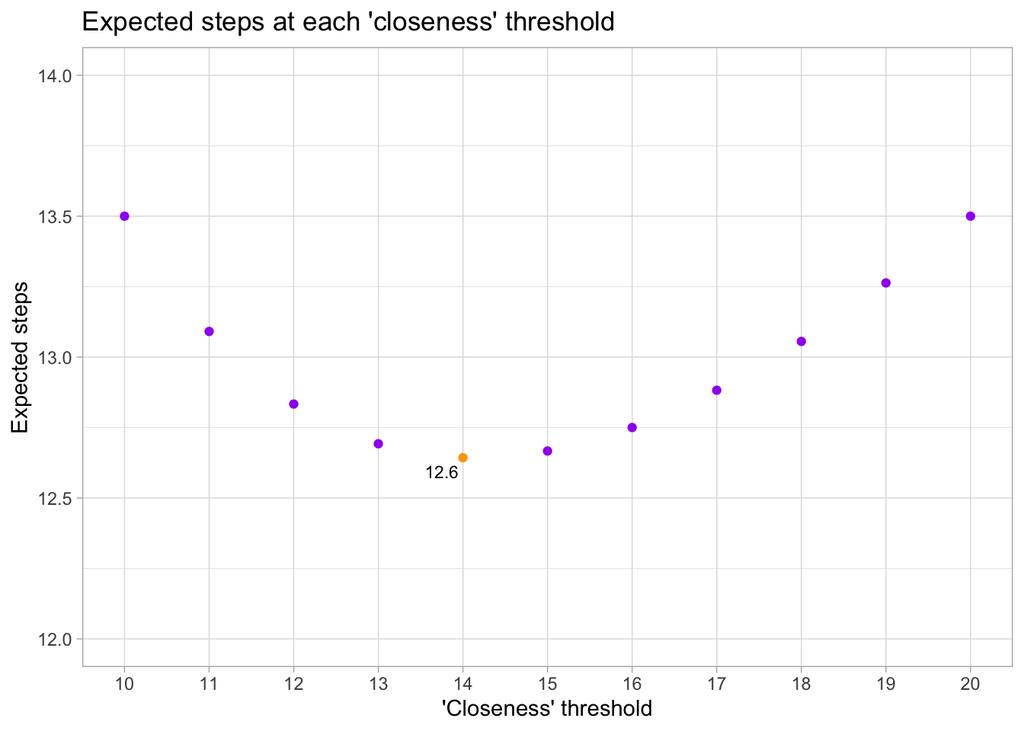

At our minimizing threshold, we get a pretty balanced mix of expected random and forward steps:

```
## # A tibble: 3 x 2
##   metric        value
##   <chr>         <dbl>
## 1 Random steps   6.14
## 2 Forward steps  6.5
## 3 Steps         12.6
```

Here we can see how that balance plays out for each possible value of the closeness threshold $n$. Not unexpectedly, when we give a crazy large threshold for closeness, the “next” buttons dominate, and that’s a linear trend.

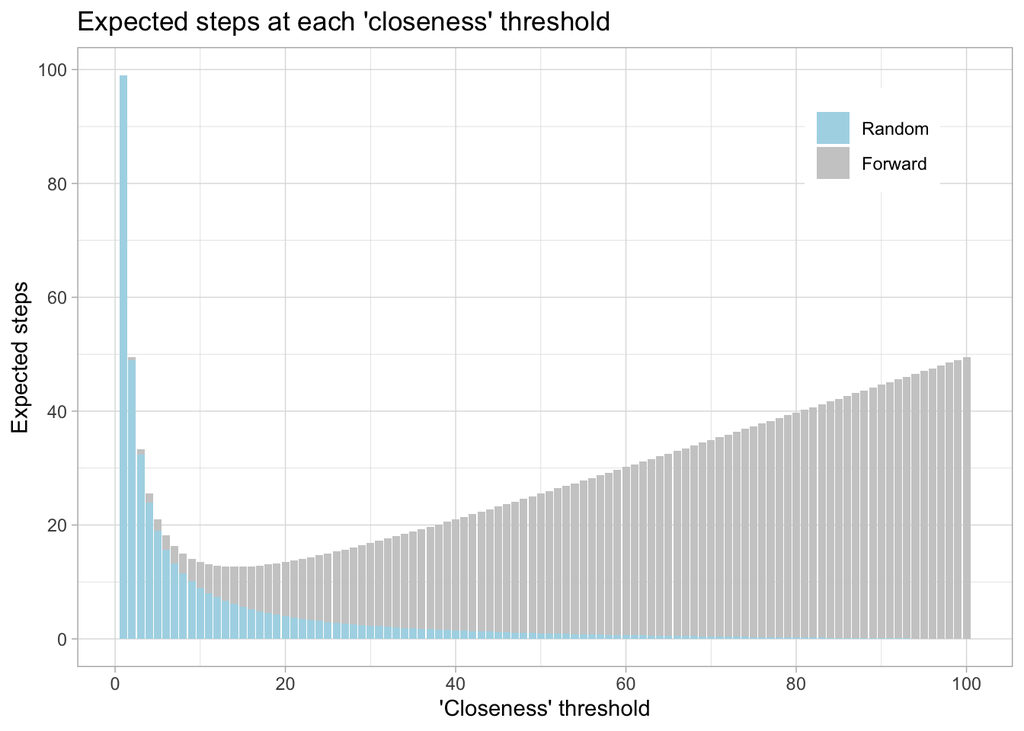

## Rule of thumb

What do we do if our number of songs isn’t $N = 100$, but some other value? We can use a little calc on our expected steps function to differentiate and find the minimum of expected steps as a function of that value $N$.

$$\begin{align*}
E[S] = & \frac{N}{n} - 1 + \frac{1}{2}(n - 1) \\
\frac{d}{dn}E[S] = & \frac{-N}{n^2} + 0 + \frac{1}{2} \\
0 = & \frac{-N}{n^2} + \frac{1}{2} \\
n^2 = & 2N \\
n = & \sqrt{2N} \\
\end{align*}$$

$$\begin{align*}
= & \sqrt{2 \cdot 100} \\
= & 14.14 \\
\end{align*}$$

## Does this hold up under trials?

Enough maths. Let’s try doing a whole bunch of trials with different cutoffs, and see what we find.

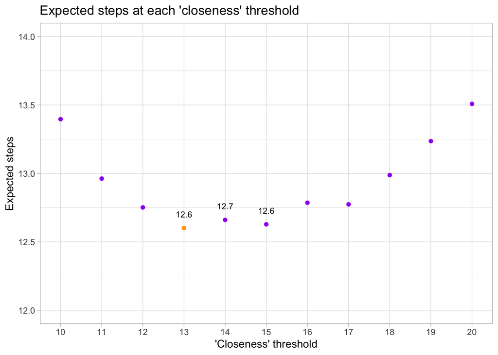

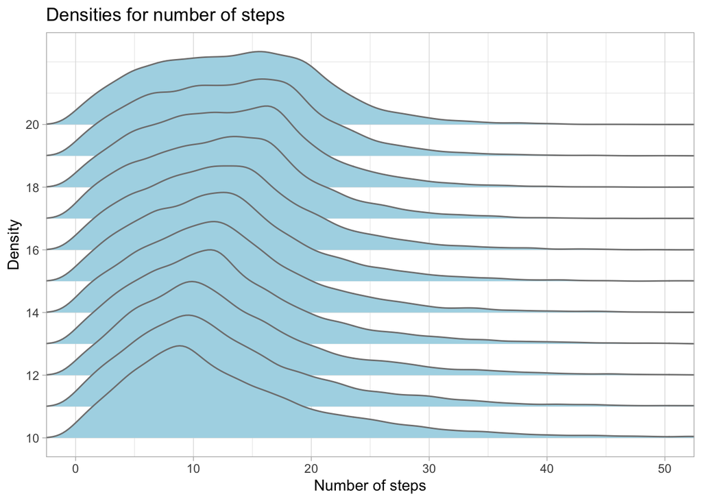

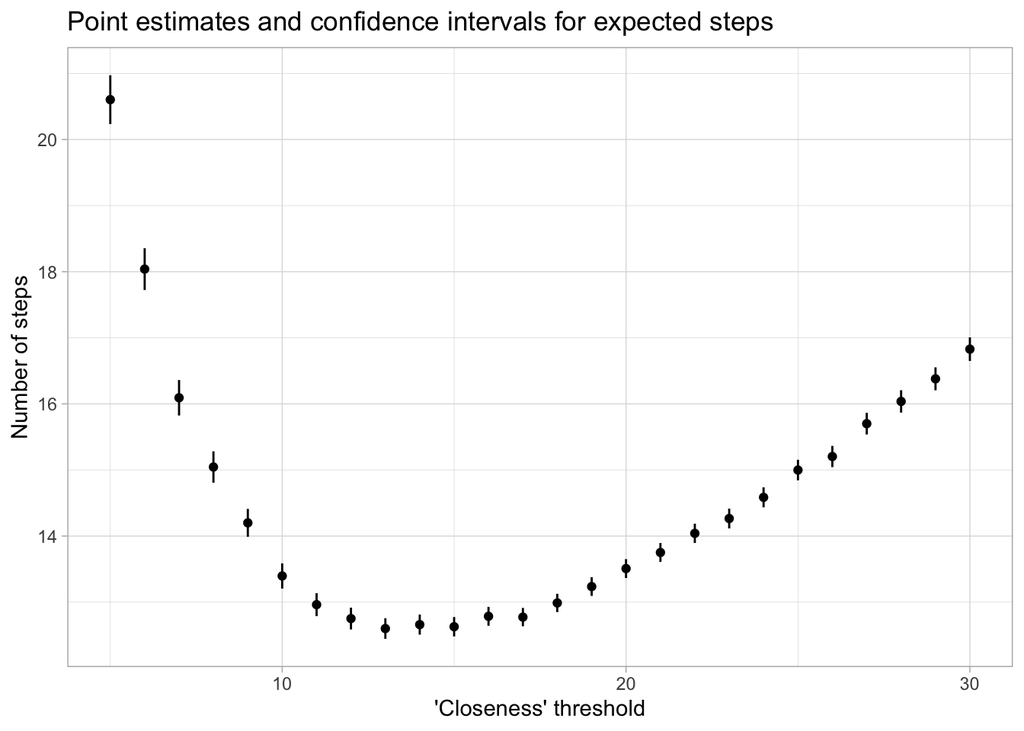